# Data Visualization Project: Arrival Performance from 2015-2019

## by Maria Soccoro Ingco

- Preliminary Wrangling
- Exploratory Analysis
- Univariate
- Bivariate
- Multivariate

## Preliminary Wrangling

> The goal of the investigation was to determine the flight performance of carriers, such as the overall on-time arrival rate, typical causes of delays and the busiest months in the year.

> The dataset used for this analysis was taken from [Bureau of Transportation Statistics](https://www.transtats.bts.gov/OT_Delay/OT_DelayCause1.asp?pn=1).

```python
# Import all packages and set plots to be embedded inline
import numpy as np
import pandas as pd
import matplotlib.pyplot as plt
import seaborn as sb

%matplotlib inline
```

```python
# Load the dataset into a pandas dataframe
flight = pd.read_csv('airline_delay.csv')
```

```python
flight.info()
```

```
<class 'pandas.core.frame.DataFrame'>
RangeIndex: 18113 entries, 0 to 18112
Data columns (total 22 columns):
 #   Column               Non-Null Count  Dtype
---  ------               --------------  -----
 0   year                 18113 non-null  int64
 1    month               18113 non-null  int64
 2   carrier              18113 non-null  object
 3   carrier_name         18113 non-null  object
 4   airport              18113 non-null  object
 5   airport_name         18113 non-null  object
 6   arr_flights          18108 non-null  float64
 7   arr_del15            18105 non-null  float64
 8   carrier_ct           18108 non-null  float64
 9    weather_ct          18108 non-null  float64
 10  nas_ct               18108 non-null  float64
 11  security_ct          18108 non-null  float64
 12  late_aircraft_ct     18108 non-null  float64
 13  arr_cancelled        18108 non-null  float64
 14  arr_diverted         18108 non-null  float64
 15   arr_delay           18108 non-null  float64
 16   carrier_delay       18108 non-null  float64
 17  weather_delay        18108 non-null  float64
 18  nas_delay            18108 non-null  float64
 19  security_delay       18108 non-null  float64
 20  late_aircraft_delay  18108 non-null  float64
 21  Unnamed: 21          0 non-null      float64
dtypes: float64(16), int64(2), object(4)
memory usage: 3.0+ MB
```

```python
# Drop unnamed columns
flight.drop(flight.columns[flight.columns.str.contains('unnamed',case = False)],axis = 1, inplace = True)

# Drop empty rows
t_flight = flight.dropna(subset = ['arr_del15'])
t_flight.info()
```

```
<class 'pandas.core.frame.DataFrame'>
Int64Index: 18105 entries, 0 to 18112
Data columns (total 21 columns):
 #   Column               Non-Null Count  Dtype
---  ------               --------------  -----
 0   year                 18105 non-null  int64
 1    month               18105 non-null  int64
 2   carrier              18105 non-null  object
 3   carrier_name         18105 non-null  object
 4   airport              18105 non-null  object
 5   airport_name         18105 non-null  object
 6   arr_flights          18105 non-null  float64
 7   arr_del15            18105 non-null  float64
 8   carrier_ct           18105 non-null  float64
 9    weather_ct          18105 non-null  float64
 10  nas_ct               18105 non-null  float64
 11  security_ct          18105 non-null  float64
 12  late_aircraft_ct     18105 non-null  float64
 13  arr_cancelled        18105 non-null  float64
 14  arr_diverted         18105 non-null  float64
 15   arr_delay           18105 non-null  float64
 16   carrier_delay       18105 non-null  float64
 17  weather_delay        18105 non-null  float64
 18  nas_delay            18105 non-null  float64
 19  security_delay       18105 non-null  float64
 20  late_aircraft_delay  18105 non-null  float64
dtypes: float64(15), int64(2), object(4)
memory usage: 3.0+ MB
```

### What is the structure of your dataset?

> The original dataset contained a total of 22 columns and 18113 rows. After removing unnamed/empty rows and columns, the final dataset used for analysis contained 21 columns and 18105 rows.

### What is/are the main feature(s) of interest in your dataset?

> The arrival and delay information.

### What features in the dataset do you think will help support your investigation into your feature(s) of interest?

> The dataset had year and month information. Also, the arrivals and delays data were both present in total count and total time.

## Univariate Exploration

- Identify the top carriers in the dataset

```python
# Carrier distribution
carrier_count = t_flight['carrier'].value_counts()
sort_carrier = carrier_count.index
```

```python
# Compute for relative carrier distribution
n_carrier = t_flight['carrier'].value_counts().sum()
max_carrier_count = carrier_count[0]
max_prop = max_carrier_count / n_carrier
max_prop
```

```
0.09942004971002485
```

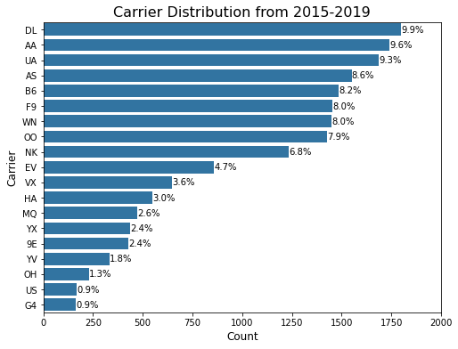

```python
# Create a chart showing counts of each carrier
tick_props = np.arange(0, max_prop, 0.02)
tick_names = ['{:0.2f}'.format(v) for v in tick_props]
base_color = sb.color_palette()[0]

plt.figure(figsize=(8,6))
sb.countplot(data=t_flight, y='carrier', order=sort_carrier, color=base_color)

for i in range (carrier_count.shape[0]):
    count = carrier_count[i]
    pct_string = '{:0.1f}%'.format(100*count/n_carrier)
    plt.text(count+1, i, pct_string, va='center')

plt.xlabel('Count', size=12)
plt.xlim(0, 2000)
plt.ylabel('Carrier', size=12)
plt.title('Carrier Distribution from 2015-2019', size=16);
```

> Delta Air (DL), American Airlines (AA) and United Airlines (UA) were the top 3 carriers from the list. These carriers were also considered as the [top carriers in the world](https://www.businessinsider.com/biggest-airlines-world-oag-2019-3) in terms of fleet size and seat capacity.
- Determine which airport is the most utilized

```python
# Airport distribution
airport_count = t_flight['airport'].value_counts()
sort_airport = airport_count.index
```

```python
# Compute for relative carrier distribution
n_airport = t_flight['airport'].value_counts().sum()
max_airport_count = airport_count[0]
max_prop2 = max_airport_count / n_airport
max_prop2
```

```
0.04059652029826015
```

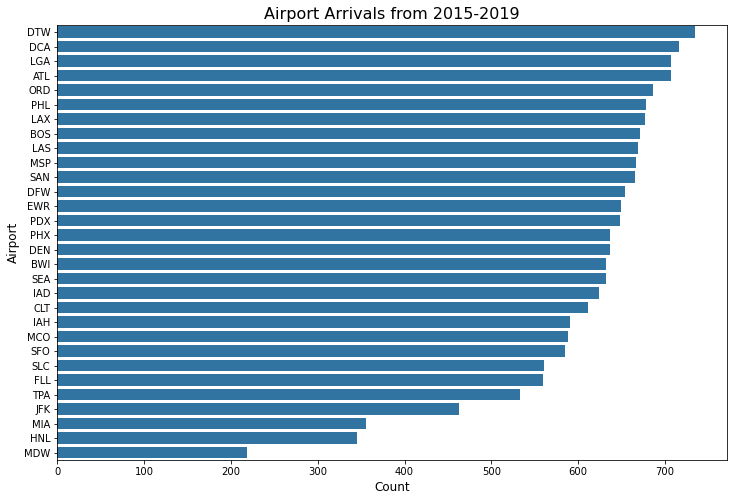

```python
# Create a chart showing counts on each airport
plt.figure(figsize=(12,8))
sb.countplot(data=t_flight, y='airport', order=sort_airport, color=base_color)
plt.xlabel('Count', size=12)
plt.ylabel('Airport', size=12)
plt.title('Airport Arrivals from 2015-2019', size=16);
```

> Detroit Metropolitan Wayne County (DTW) had the most arrivals based on the dataset. It is also considered as one of the [largest airport in the US](https://www.airport-technology.com/features/largest-airports-america/).
- Look how the arrivals and delays are distributed

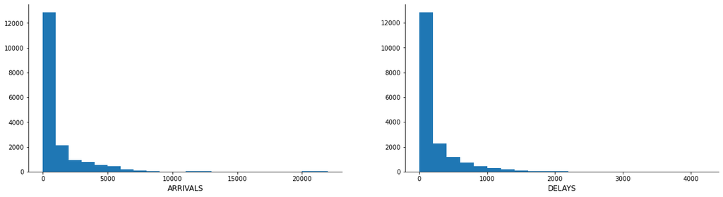

```python
# Create a side-by-side of arrival and delay distribution
plt.figure(figsize = [20, 5])

# histogram on left, arrivals
plt.subplot(1, 2, 1)
bins = np.arange(0, t_flight['arr_flights'].max()+1000, 1000)
plt.hist(data = t_flight, x = 'arr_flights', bins=bins)
plt.xlabel('ARRIVALS', size=12)
plt.ylabel('')
sb.despine();

# histogram on right, delays
plt.subplot(1, 2, 2)
bins = np.arange(0, t_flight['arr_del15'].max()+200, 200)
plt.hist(data = t_flight, x = 'arr_del15', bins=bins)
plt.xlabel('DELAYS', size=12)
plt.ylabel('')
sb.despine();
```

> Arrivals and delays distribution were both right-skewed. There were very few carriers that had over 10,000 arrivals or 2,000 delays.

```python
# Transform the describe() to a scale of log10
np.log10(t_flight['arr_flights'].describe())
```

```
count    4.257799
mean     3.063709
std      3.294409
min      0.000000
25%      2.139879
50%      2.654177
75%      3.077731
max      4.341968
Name: arr_flights, dtype: float64
```

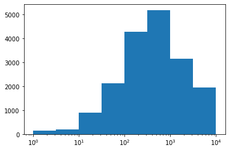

```python
# Scale the x-axis to log-type and change the axis limit
bins = 10 ** np.arange(0, 4+0.5, 0.5)
plt.hist(data=t_flight, x='arr_flights', bins=bins)
plt.xscale('log');
```

> By transforming the arrivals data, it was observed that it also had a normal distribution.

### Discuss the distribution(s) of your variable(s) of interest. Were there any unusual points? Did you need to perform any transformations?

> The carrier and airport distributions were normal. However, it was not the same for arrivals and delays distribution, both of which were highly skewed to the right.

### Of the features you investigated, were there any unusual distributions? Did you perform any operations on the data to tidy, adjust, or change the form of the data? If so, why did you do this?

> Because of the unsual distributions for arrivals and delays, transformation was necessary to have a better view on the distribution. However, it can only be done on the arrivals data. There were instances that no delays happened so certain cells in delays had '0' entries. Thus transformation was not possible.

## Bivariate Exploration

- Determine the total and average arrivals and delays per year

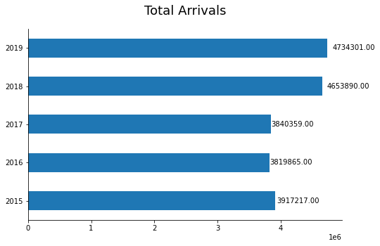

```python
# Create chart showing total arrivals per year
plt.figure(figsize=(8, 5))
plot1 = t_flight.groupby(['year'])['arr_flights'].sum().plot.barh()

for p in plot1.patches:
    width = p.get_width()
    plt.text(1.09*p.get_width(), p.get_y()+0.5*p.get_height(),
             '{:1.2f}'.format(width),
             ha='center', va='center')

plt.title('Total Arrivals', size = 18, pad = 20)
plt.ylabel('')
sb.despine();
```

> There had been a significant increase in the number of arrivals between 2017 and 2018. The trend continued to increase in 2019 but on a much lower rate.

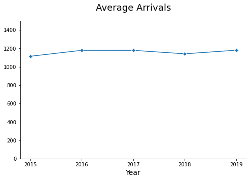

```python
# Create a chart showing average arrivals
ticks = [2015, 2016, 2017, 2018, 2019]
labels = ['{}'.format(v) for v in ticks]

plt.figure(figsize=(8, 5))
sb.lineplot(data=t_flight.groupby(['year'])['arr_flights'].mean(), color = base_color, marker = 'D')
plt.xticks(ticks, labels)
plt.ylim(0, 1500)
plt.title('Average Arrivals', size = 18, pad = 20)
plt.xlabel('Year', size = 14)
plt.ylabel('')
sb.despine();
```

> Between 2017 and 2018, the average arrivals went down, different from the previous trend observed.

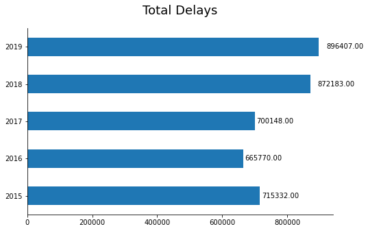

```python
# Create chart showing total delays per year
plt.figure(figsize=(8, 5))
plot2 = t_flight.groupby(['year'])['arr_del15'].sum().plot.barh()

for p in plot2.patches:
    width = p.get_width()
    plt.text(1.09*p.get_width(), p.get_y()+0.5*p.get_height(),
             '{:1.2f}'.format(width),
             ha='center', va='center')

plt.title('Total Delays', size = 18, pad = 20)
plt.ylabel('')
sb.despine();
```

> There was also a significant increase in total delays between 2017 and 2018, similar to the trend observed on the total arrivals.

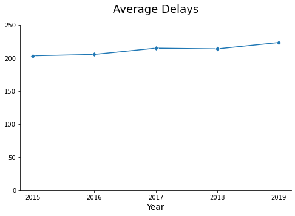

```python
# Create a chart showing average delays
plt.figure(figsize=(8, 5))
sb.lineplot(data=t_flight.groupby(['year'])['arr_del15'].mean(), color = base_color, marker = 'D')
plt.xticks(ticks, labels)
plt.title('Average Delays', size = 18, pad = 20)
plt.xlabel('Year', size = 14)
plt.ylabel('')
plt.ylim(0, 250)
sb.despine();
```

> Even though there was a slight decrease in the average delays between 2017-2018, in general, the trend of average delays was increasing.
- Identify the overall all on-time performance.

```python
# Get sum of total arrivals and delays
arrival = t_flight.arr_flights.sum()
delay = t_flight[['carrier_ct', ' weather_ct', 'nas_ct', 'security_ct', 'late_aircraft_ct',
                  'arr_cancelled', 'arr_diverted']].sum().sum()
```

```python
# Compute on-time arrival rate and delayed arrival rate
del_rate = delay / arrival
arr_rate = 1 - del_rate
```

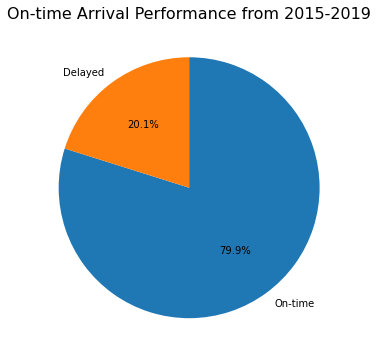

```python
# Create a chart showing on-time performance
plt.figure(figsize=(6, 6))
plt.pie([arr_rate, del_rate], labels=['On-time', 'Delayed'], autopct='%1.1f%%', startangle=90, counterclock=False)
plt.title('On-time Arrival Performance from 2015-2019', size = 16);
```

> Flights arrived on-time ~80% of the time.
- Rank the reasons for delay based on their relative contribution to the overall delay

```python
# Compute percentage of each cause of delay
carrier = 100 * t_flight.carrier_ct.sum() / delay
weather = 100 * t_flight[[' weather_ct']].sum() / delay
nas = 100 * t_flight.nas_ct.sum() / delay
security = 100 * t_flight.security_ct.sum() / delay
late = 100 * t_flight.late_aircraft_ct.sum() / delay
cancelled = 100 * t_flight.arr_cancelled.sum() / delay
diverted = 100 * t_flight.arr_diverted.sum() / delay
```

```python
# Create a list containing rate of each reason for delay
list = [['Carrier', carrier], ['Weather', weather], ['NAS', nas], ['Security', security], ['Late Aircraft', late],
        ['Cancelled', cancelled], ['Diverted', diverted]]

# Store list in a data frame
reason = pd.DataFrame(list, columns=['reason', 'rate'], dtype=float)
reason
```

|  | reason | rate |
| --- | --- | --- |
| 0 | Carrier | 23.440581 |
| 1 | Weather | 2.835288 |
| 2 | NAS | 32.895592 |
| 3 | Security | 0.163419 |
| 4 | Late Aircraft | 31.822380 |
| 5 | Cancelled | 7.619145 |
| 6 | Diverted | 1.223594 |

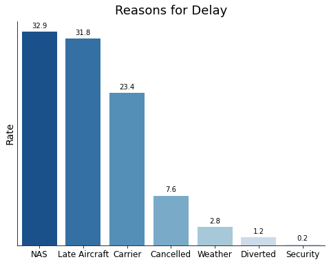

```python
# Sort data in descending order
del_order = reason.sort_values(by = ['rate'], ascending = False, inplace = True)

# Create a chart showing the different reasons for delay
plt.figure(figsize=(8, 6))
plot2 = sb.barplot(x='reason', y='rate', data=reason, palette='Blues_r')

for p in plot2.patches:
    plot2.annotate(format(p.get_height(), '.1f'),
                   (p.get_x() + p.get_width() / 2., p.get_height()),
                   ha = 'center', va = 'center',
                   xytext = (0, 9), textcoords = 'offset points')

plt.title('Reasons for Delay', size = 18, pad = 10)
plt.xlabel('')
plt.xticks(size=12)
plt.ylabel('Rate', size = 14)
plt.yticks([], [])
sb.despine();
```

> The reasons for delay in descending order: national aviation system (NAS), late aircraft, carrier delay, cancelled flight, weather delay, diverted flights and security delay.

### Talk about some of the relationships you observed in this part of the investigation. How did the feature(s) of interest vary with other features in the dataset?

> The total number of arrivals and delays showed a significant increase in 2018. However, the average arrivals per year had a very little change. The increasing trend in average delays, on the other hand, was much more visible than that of the average arrivals.

### Did you observe any interesting relationships between the other features (not the main feature(s) of interest)?

> Flights arrived on-time ~80% of the time and the top reason for delay was due to national aviation system at 32.9%, which according to [Bureau of Transportation Statistics](https://www.transtats.bts.gov/OT_Delay/ot_delaycause1.asp?6B2r=I&20=E) includes weather condition, high volume of flights, and closed runways.

## Multivariate Exploration

- Explore arrivals and delays relationship

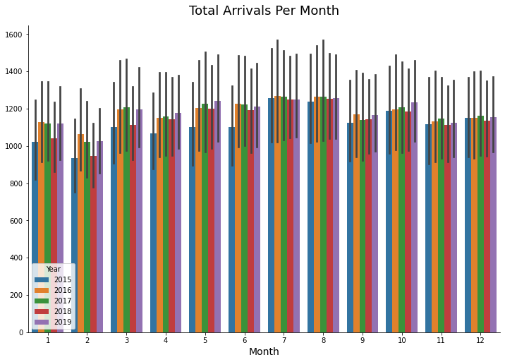

```python
# Create chart showing arrivals per month each year
plt.figure(figsize=(12, 8))
sb.barplot(x = ' month', y = 'arr_flights', hue='year', data = t_flight)
plt.title('Total Arrivals Per Month', size = 18, pad = 15)
plt.xlabel('Month', size=14)
plt.ylabel('')
plt.legend(title='Year', loc=3)
sb.despine();
```

> July and August had the most arrivals per year.

```python
# Get % delay of each carrier
del_percent = t_flight['arr_del15'] / t_flight['arr_flights']

# Add % delay column into the dataframe
t_flight['%_delay'] = del_percent
t_flight.head()
```

|  | year | month | carrier | carrier_name | airport | airport_name | arr_flights | arr_del15 | carrier_ct | weather_ct | ... | late_aircraft_ct | arr_cancelled | arr_diverted | arr_delay | carrier_delay | weather_delay | nas_delay | security_delay | late_aircraft_delay | %_delay |
| --- | --- | --- | --- | --- | --- | --- | --- | --- | --- | --- | --- | --- | --- | --- | --- | --- | --- | --- | --- | --- | --- |
| 0 | 2016 | 11 | OO | SkyWest Airlines Inc. | BWI | Baltimore, MD: Baltimore/Washington Internatio... | 80.0 | 15.0 | 6.63 | 0.00 | ... | 5.57 | 0.0 | 0.0 | 1674.0 | 1280.0 | 0.0 | 82.0 | 0.0 | 312.0 | 0.187500 |
| 1 | 2016 | 11 | OO | SkyWest Airlines Inc. | LGA | New York, NY: LaGuardia | 3.0 | 0.0 | 0.00 | 0.00 | ... | 0.00 | 0.0 | 0.0 | 0.0 | 0.0 | 0.0 | 0.0 | 0.0 | 0.0 | 0.000000 |
| 2 | 2016 | 11 | OO | SkyWest Airlines Inc. | IAD | Washington, DC: Washington Dulles International | 31.0 | 10.0 | 1.88 | 1.25 | ... | 5.12 | 0.0 | 0.0 | 669.0 | 269.0 | 100.0 | 91.0 | 0.0 | 209.0 | 0.322581 |
| 3 | 2016 | 11 | OO | SkyWest Airlines Inc. | DCA | Washington, DC: Ronald Reagan Washington National | 12.0 | 2.0 | 1.00 | 0.00 | ... | 0.00 | 0.0 | 0.0 | 37.0 | 20.0 | 0.0 | 17.0 | 0.0 | 0.0 | 0.166667 |
| 4 | 2016 | 11 | UA | United Air Lines Inc. | LAX | Los Angeles, CA: Los Angeles International | 2323.0 | 478.0 | 131.46 | 5.77 | ... | 97.29 | 6.0 | 5.0 | 22451.0 | 6858.0 | 436.0 | 7906.0 | 0.0 | 7251.0 | 0.205768 |

5 rows × 22 columns

```python
# Create pivot table showing % delay per month
pivot1 = t_flight.pivot_table(values='%_delay', index=' month', columns='year').fillna(0)
round(pivot1, 2)
```

| year month | 2015 | 2016 | 2017 | 2018 | 2019 |
| --- | --- | --- | --- | --- | --- |
| 1 | 0.23 | 0.17 | 0.25 | 0.19 | 0.21 |
| 2 | 0.25 | 0.17 | 0.19 | 0.20 | 0.25 |
| 3 | 0.21 | 0.20 | 0.21 | 0.18 | 0.19 |
| 4 | 0.18 | 0.17 | 0.22 | 0.20 | 0.20 |
| 5 | 0.20 | 0.17 | 0.23 | 0.21 | 0.23 |
| 6 | 0.25 | 0.22 | 0.25 | 0.24 | 0.26 |
| 7 | 0.23 | 0.24 | 0.23 | 0.25 | 0.24 |
| 8 | 0.20 | 0.23 | 0.21 | 0.25 | 0.23 |
| 9 | 0.15 | 0.17 | 0.14 | 0.19 | 0.17 |
| 10 | 0.14 | 0.16 | 0.16 | 0.19 | 0.19 |
| 11 | 0.17 | 0.15 | 0.13 | 0.22 | 0.16 |
| 12 | 0.23 | 0.25 | 0.19 | 0.20 | 0.23 |

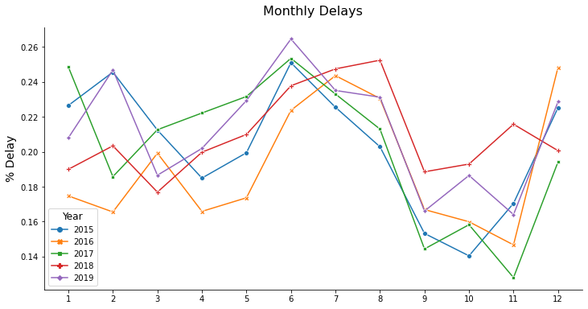

```python
# Create a chart showing in-month % delay
mticks = [1, 2, 3, 4, 5, 6, 7, 8, 9, 10, 11, 12]
mlabels = ['{}'.format(v) for v in mticks]
plt.figure(figsize = (12,6))
sb.lineplot(data=pivot1, markers=True, dashes=False)
plt.xticks(mticks, mlabels)
plt.title('Monthly Delays', size = 16, pad = 15)
plt.xlabel('')
plt.ylabel('% Delay', size = 14)
plt.legend(title='Year', loc=0, fontsize='medium', title_fontsize='large')
sb.despine();
```

> Delays typically peaked in June, the start of summer season.

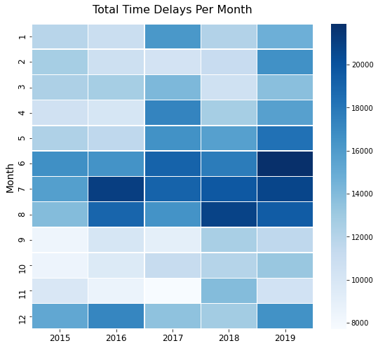

```python
# Create a pivot table showing total time delay per month per year
pivot2 = t_flight.pivot_table(values=' arr_delay', index=' month', columns='year').fillna(0)

# Create a chart showing time delays per month per year
plt.figure(figsize=(9, 8))
sb.heatmap(pivot2, cmap='Blues', linewidths = 0.5)
plt.title('Total Time Delays Per Month', size=16, pad=15)
plt.xlabel('')
plt.xticks(size=12)
plt.ylabel('Month', size=14)
plt.yticks(size=12);
```

> Total time delays were the highest during the summer season, from June to August, where people were mostly on vacation.
- Identify which carrier had the most arrivals per airport

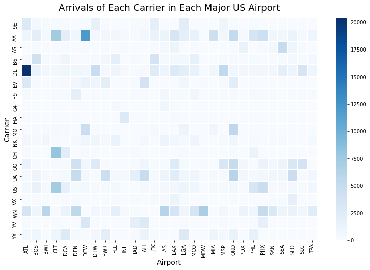

```python
# Create a pivot table showing the number of arrivals of each carrier in each airport
pivot3 = t_flight.pivot_table(values='arr_flights', index='carrier', columns='airport').fillna(0)

#Create a heatmap showing number of arrivals of each carrier in each airport
plt.figure(figsize=(13, 8))
sb.heatmap(pivot3, cmap='Blues', linewidths=0.5)
plt.xlabel('Airport', size=14)
plt.ylabel('Carrier', size=14)
plt.title('Arrivals of Each Carrier in Each Major US Airport', size=18, pad=15);
```

> As shown in previous graph, Delta Air had the most arrivals among all carriers. Its main headquarters is at Hartsfield Jackson International (ATL).

```python
# Create a pivot table showing % delay of each carrier in each airport
pivot4 = t_flight.pivot_table(values='%_delay', index='carrier', columns='airport').fillna(0)
round(pivot4, 2)
```

| airport carrier | ATL | BOS | BWI | CLT | DCA | DEN | DFW | DTW | EWR | FLL | ... | MSP | ORD | PDX | PHL | PHX | SAN | SEA | SFO | SLC | TPA |
| --- | --- | --- | --- | --- | --- | --- | --- | --- | --- | --- | --- | --- | --- | --- | --- | --- | --- | --- | --- | --- | --- |
| 9E | 0.16 | 0.20 | 0.17 | 0.19 | 0.17 | 0.12 | 0.18 | 0.13 | 0.32 | 0.23 | ... | 0.14 | 0.22 | 0.00 | 0.22 | 0.00 | 0.00 | 0.00 | 0.00 | 0.00 | 0.20 |
| AA | 0.21 | 0.21 | 0.21 | 0.15 | 0.19 | 0.22 | 0.17 | 0.19 | 0.31 | 0.22 | ... | 0.21 | 0.19 | 0.22 | 0.18 | 0.16 | 0.22 | 0.24 | 0.28 | 0.21 | 0.21 |
| AS | 0.13 | 0.16 | 0.13 | 0.00 | 0.15 | 0.17 | 0.12 | 0.13 | 0.24 | 0.16 | ... | 0.15 | 0.17 | 0.12 | 0.15 | 0.14 | 0.15 | 0.16 | 0.23 | 0.13 | 0.14 |
| B6 | 0.25 | 0.24 | 0.22 | 0.21 | 0.21 | 0.28 | 0.22 | 0.26 | 0.34 | 0.26 | ... | 0.27 | 0.30 | 0.22 | 0.25 | 0.29 | 0.20 | 0.24 | 0.27 | 0.25 | 0.25 |
| DL | 0.12 | 0.19 | 0.12 | 0.13 | 0.15 | 0.15 | 0.15 | 0.11 | 0.26 | 0.15 | ... | 0.12 | 0.18 | 0.13 | 0.16 | 0.14 | 0.13 | 0.15 | 0.23 | 0.11 | 0.15 |
| EV | 0.18 | 0.20 | 0.20 | 0.25 | 0.21 | 0.17 | 0.25 | 0.19 | 0.30 | 0.00 | ... | 0.19 | 0.20 | 0.00 | 0.16 | 0.07 | 0.00 | 0.00 | 0.00 | 0.22 | 0.00 |
| F9 | 0.25 | 0.23 | 0.25 | 0.25 | 0.23 | 0.23 | 0.26 | 0.20 | 0.33 | 0.20 | ... | 0.24 | 0.26 | 0.25 | 0.27 | 0.26 | 0.24 | 0.27 | 0.35 | 0.26 | 0.23 |
| G4 | 0.00 | 0.00 | 0.19 | 0.00 | 0.00 | 0.34 | 0.00 | 0.00 | 0.08 | 0.34 | ... | 0.00 | 0.00 | 0.00 | 0.00 | 0.00 | 0.20 | 0.00 | 0.00 | 0.00 | 0.00 |
| HA | 0.00 | 0.30 | 0.00 | 0.00 | 0.00 | 0.00 | 0.00 | 0.00 | 0.00 | 0.00 | ... | 0.00 | 0.00 | 0.26 | 0.00 | 0.22 | 0.23 | 0.31 | 0.21 | 0.00 | 0.00 |
| MQ | 0.21 | 0.26 | 0.20 | 0.18 | 0.14 | 0.00 | 0.18 | 0.24 | 0.31 | 0.00 | ... | 0.25 | 0.20 | 0.00 | 0.21 | 0.00 | 0.00 | 0.00 | 0.00 | 0.19 | 0.00 |
| NK | 0.23 | 0.23 | 0.21 | 0.27 | 0.00 | 0.21 | 0.22 | 0.21 | 0.29 | 0.21 | ... | 0.22 | 0.24 | 0.22 | 0.26 | 0.22 | 0.20 | 0.22 | 0.00 | 0.00 | 0.22 |
| OH | 0.22 | 0.19 | 0.19 | 0.16 | 0.21 | 0.00 | 0.27 | 0.18 | 0.38 | 0.00 | ... | 0.38 | 0.17 | 0.00 | 0.20 | 0.00 | 0.00 | 0.00 | 0.00 | 0.00 | 0.00 |
| OO | 0.20 | 0.24 | 0.17 | 0.23 | 0.22 | 0.16 | 0.22 | 0.16 | 0.36 | 0.28 | ... | 0.15 | 0.22 | 0.12 | 0.26 | 0.12 | 0.15 | 0.17 | 0.26 | 0.12 | 0.35 |
| UA | 0.19 | 0.22 | 0.19 | 0.20 | 0.20 | 0.14 | 0.21 | 0.20 | 0.24 | 0.20 | ... | 0.19 | 0.17 | 0.19 | 0.22 | 0.20 | 0.17 | 0.21 | 0.22 | 0.19 | 0.20 |
| US | 0.22 | 0.22 | 0.20 | 0.15 | 0.20 | 0.22 | 0.23 | 0.18 | 0.22 | 0.21 | ... | 0.21 | 0.22 | 0.19 | 0.20 | 0.15 | 0.17 | 0.17 | 0.23 | 0.15 | 0.17 |
| VX | 0.00 | 0.18 | 0.07 | 0.00 | 0.19 | 0.21 | 0.00 | 0.00 | 0.25 | 0.23 | ... | 0.00 | 0.22 | 0.23 | 0.08 | 0.00 | 0.22 | 0.22 | 0.26 | 0.00 | 0.00 |
| WN | 0.17 | 0.22 | 0.15 | 0.24 | 0.18 | 0.17 | 0.00 | 0.20 | 0.30 | 0.17 | ... | 0.20 | 0.00 | 0.19 | 0.21 | 0.19 | 0.18 | 0.24 | 0.29 | 0.21 | 0.17 |
| YV | 0.23 | 0.18 | 0.30 | 0.20 | 0.16 | 0.00 | 0.21 | 0.19 | 0.00 | 0.05 | ... | 0.21 | 0.00 | 0.08 | 0.16 | 0.17 | 0.00 | 0.00 | 0.00 | 0.20 | 0.26 |
| YX | 0.18 | 0.21 | 0.09 | 0.14 | 0.15 | 0.15 | 0.22 | 0.17 | 0.27 | 0.33 | ... | 0.19 | 0.18 | 0.00 | 0.15 | 0.00 | 0.00 | 0.22 | 0.00 | 0.16 | 0.04 |

19 rows × 30 columns

- Identify which carrier had the highest % delay in each airport

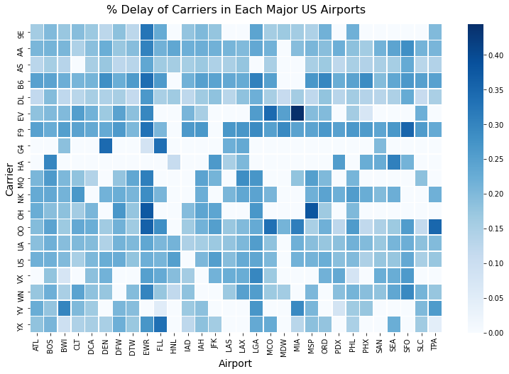

```python
# Create a chart showing % delay of each carrier in each airport
plt.figure(figsize=(13, 8))
sb.heatmap(pivot4, cmap='Blues', linewidths=0.5)
plt.title('% Delay of Carriers in Each Major US Airports', size = 16, pad = 15)
plt.xlabel('Airport', size = 14)
plt.ylabel('Carrier', size = 14);
```

```python
# Get average minutes of delay
car_ave = t_flight[' carrier_delay'].mean()
wea_ave = t_flight['weather_delay'].mean()
nas_ave = t_flight['nas_delay'].mean()
sec_ave = t_flight['security_delay'].mean()
late_ave = t_flight['late_aircraft_delay'].mean()
```

```python
# Create a list containing total minutes of each reason for delay
list2 = [['Carrier', car_ave], ['NAS', nas_ave],
         ['Security', sec_ave], ['Late Aircraft', late_ave]]

# Store list in a data frame
time_ave = pd.DataFrame(list2, columns = ['reason_t', 'ave'], dtype = float)
time_ave
```

|  | reason_t | ave |
| --- | --- | --- |
| 0 | Carrier | 4114.679260 |
| 1 | NAS | 3961.876388 |
| 2 | Security | 18.685501 |
| 3 | Late Aircraft | 5342.529357 |

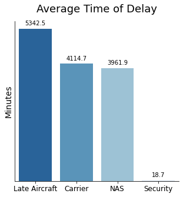

```python
# Sort data in descending order
time_order = time_ave.sort_values(by=['ave'], ascending=False, inplace=True)

#Create a bar chart showing the reasons for delay
plt.figure(figsize=(5, 5))
plot3 = sb.barplot(x='reason_t', y='ave', data=time_ave, palette='Blues_r')

for p in plot3.patches:
    plot3.annotate(format(p.get_height(), '.1f'),
                   (p.get_x() + p.get_width() / 2., p.get_height()),
                   ha = 'center', va = 'center',
                   xytext = (0, 9), textcoords = 'offset points')

plt.title('Average Time of Delay', size = 18, pad = 15)
plt.xlabel('')
plt.ylabel('Minutes', size = 14)
plt.xticks(size=12)
plt.yticks([], [])
sb.despine();
```

> On average, late aircraft was causing the longest time delay, ~5,000 minutes. Cancelled and diverted flights have no time attribute, thus were removed from the list.

### Talk about some of the relationships you observed in this part of the investigation. Were there features that strengthened each other in terms of looking at your feature(s) of interest?

> In general, the higher number of arrivals, the higher number and the longer time of delays. It was seen that during the months of June to August that the highest number of arrivals and delays and the longest time delays were recorded.

### Were there any interesting or surprising interactions between features?

```python
! jupyter nbconvert --to html exploration_template.ipynb
```